# Critical Mineral Accelerator Engine: knowledge base

NSF Regional Innovation Engines, Cohort 2. Technology profile v1. Draft, in progress

**NSF Critical Mineral Accelerator Engine in Alaska**, led by University of Alaska Fairbanks Campus. NSF award 2532372, start August 2026. Search window for papers and patents: from August 2021 (five years before the award) onward.

## At a glance

| Measure | Value |
| --- | --- |
| People named by NSF or the Engine’s site | 10 |
| of them active researchers (>= 5 works since window start) | 5 |
| Team members who are inventors (2021-2025 grants, in the region) | 0 |
| Partners (site list + team members’ organisations) | 47 |
| Knowledge-producer partners (universities, labs, institutes) | 10 |
| Partner papers in the Engine’s topics | 753 |
| of them with an in-region partner | 41 |
| Regional patents in the technology profile (2021-2025 grants) | 4 |
| Location quotient of the technology profile (patents) | 0.2 |
| Share of regional technology patents owned by partners | 0.0% |

## Economic base

| NAICS | Industry | Employment in region | Establishments | Share of US employment | Employment LQ |
| --- | --- | --- | --- | --- | --- |
| 212 | Mining (except oil and gas) | 3,250 | 70 | 1.9% | 9.92 |
| 2131 | Support activities for mining | 4,845 | 72 | 1.7% | 8.91 |

Industries related to the Engine’s technology (chosen from the NSF abstract, see `data/manual/engine_naics.csv`). County Business Patterns 2023; LQ = the industry’s share of regional employment relative to its share of US employment (1 = US average). Region: whole state(s).

## Technology profile

Version 1. The profile has 3 statements. Item 1 comes from the grant title, the rest from the technical part of the NSF abstract. Each statement is mapped to one OpenAlex topic and to CPC codes.

| # | Source | Statement | OpenAlex topic | Subfield | CPC |
| --- | --- | --- | --- | --- | --- |
| 1 | title | Critical mineral exploration, extraction, recovery and production | Extraction and Separation Processes | Metals and Alloys | C22B; G01V |
| 2 | abstract | AI-based mineral discovery integrating geological, geochemical, geophysical and remote-sensing data, including metal-isotope geochemistry | Geochemistry and Geologic Mapping | Geochemistry and Petrology | G01V; G06N |
| 3 | abstract | Recovery of critical minerals from low-grade ore and mine waste by bio-based extraction and mineral processing | Metal Extraction and Bioleaching | Metals and Alloys | C22B3; B03D |

## People

| Role | People |
| --- | --- |
| organizer | 5 |
| researcher | 4 |
| research_admin | 1 |

| Name | Role | On NSF award | Title | Organisation | Works since window (in Engine topics) | h-index | Patents 2021-25 (in Engine profile) | Site | OpenAlex |
| --- | --- | --- | --- | --- | --- | --- | --- | --- | --- |
| Florian Hofmann | researcher |  |  | University of Alaska Fairbanks (implied) | 33 (1) | 6 |  | [page](https://engine.alaska.edu/about/) | [profile](https://openalex.org/A5103172281) |
| Lee Ann Munk | researcher | PI | CEO and Co-Founder | NSF Critical Mineral Accelerator Engi… | 64 (6) | 22 |  | [page](https://engine.alaska.edu/about/) | [profile](https://openalex.org/A5024668058) |
| Nathan Graham | researcher |  |  | University of Alaska Fairbanks (implied) | 8 (0) | 7 |  | [page](https://engine.alaska.edu/about/) | [profile](https://openalex.org/A5002875756) |
| Sean Regan | researcher |  |  | University of Alaska Fairbanks (implied) | 63 (12) | 19 |  | [page](https://engine.alaska.edu/about/) | [profile](https://openalex.org/A5042227941) |
| Erin Whitney | research_admin | Co-PI | Engine Liaison; Associate Vice Chancellor for Research | University of Alaska Fairbanks | 12 (0) | 12 |  | [page](https://engine.alaska.edu/about/) | [profile](https://openalex.org/A5054913695) |
| Christi Bell | organizer | Co-PI | COO and Co-Founder | NSF Critical Mineral Accelerator Engi… | - | - |  | [page](https://engine.alaska.edu/about/) |  |
| Lance Miller | organizer | Co-PI | External Advisory Board Chair; Vice President of Natural … | NANA Regional Corporation | - | - |  | [page](https://engine.alaska.edu/about/) |  |
| Liz Dennett | organizer | Co-PI | Advisor RD&T and Innovation; Founder and CEO | Endolith Mining | - | - |  | [page](https://engine.alaska.edu/about/) |  |
| Mark Lambert | organizer |  | Executive Director of Commercialization | NSF Critical Mineral Accelerator Engi… | - | - |  | [page](https://engine.alaska.edu/about/) |  |
| Steven S Masterman | organizer | Co-PI |  |  | - | - |  |  |  |

Publication counts are shown only where the OpenAlex author matches both the name and the person’s current organisation. The OpenAlex link is given only for these reliable matches, and not for profiles flagged as possibly merging several namesakes. *Site* links to the page of the Engine’s website where the person is named. Click a number of works to see the list on the Publications page. *Patents*: US grants 2021-2025 with the person among the inventors (same last and first name, address in the Engine’s states); click the number for the list on the Patents page. In brackets: works in the Engine’s topics, patents with a CPC code in the Engine’s technology profile.

## Researchers at partner organisations

| # | Researcher | Partner | Works in the Engine’s topics | Citations | Years | Most cited of these works |
| --- | --- | --- | --- | --- | --- | --- |
| 1 | [Brandon R. Briggs](https://openalex.org/A5010495699) | University of Alaska Anchorage | 8 | 14 | 2022-2026 | [Microbial iron acquisition is influenced by spatial and t…](https://openalex.org/W4388620202) |
| 2 | [LeeAnn Munk](https://openalex.org/A5024668058) (team) | University of Alaska Anchorage; University of Alaska Fairbanks | 5 | 213 | 2021-2025 | [Lithium Brines: Origin, Characteristics, and Global Distr…](https://openalex.org/W4408699309) |
| 3 | [Társilo Girona](https://openalex.org/A5075929881) | University of Alaska Fairbanks | 5 | 4 | 2022-2026 | [A drone-based prototype technique for monitoring soil deg…](https://openalex.org/W4415452419) |
| 4 | [Sean P. Regan](https://openalex.org/A5042227941) (team) | University of Alaska Fairbanks | 5 | 3 | 2023-2026 | [U-Pb zircon geochronology of bedrock samples collected in…](https://openalex.org/W4386468195) |
| 5 | [Subhabrata Dev](https://openalex.org/A5086160731) | University of Alaska Fairbanks | 4 | 7 | 2022-2024 | [Bioweathering Using Shewanella oneidensis MR-1 Enhances R…](https://openalex.org/W4387664659) |
| 6 | [Srijan Aggarwal](https://openalex.org/A5090192210) | University of Alaska Fairbanks | 3 | 6 | 2022-2023 | [Bioweathering Using Shewanella oneidensis MR-1 Enhances R…](https://openalex.org/W4387664659) |

The grant names mostly managers; the technology is often developed at the partner universities and labs. These are the authors with the most works in the Engine’s OpenAlex topics written at a knowledge-producer partner in the Engine’s states, since the window start (at least 3 works; top 15). The list depends on the technology profile version. OpenAlex sometimes merges namesakes into one author: check the profile before relying on a name.

## Partners

| Organisation class | Partners |
| --- | --- |
| company | 20 |
| intermediary | 7 |
| investor | 6 |
| national_lab | 5 |
| government | 4 |
| university | 4 |
| research_institute | 1 |

Partner list on the site: *Complete (46 organisations)*.

| Partner | Class | State | OpenAlex works since window (all topics) |
| --- | --- | --- | --- |
| Pacific Northwest National Laboratory | national_lab | Washington | 1362797 |
| Los Alamos National Laboratory | national_lab | New Mexico | 32292 |
| Colorado School of Mines | university | Colorado | 17985 |
| National Laboratory of the Rockies | national_lab | Colorado | 17683 |
| Idaho National Laboratory | national_lab | Idaho | 7974 |
| University of Alaska Fairbanks | university | Alaska | 7847 |
| University of Alaska Anchorage | university | Alaska | 2474 |
| Ames National Laboratory | national_lab | Iowa | 2230 |
| University of Alaska | university | Alaska | 96 |
| Critical Materials Innovation Hub | research_institute |  | NA |

## Science base: partner papers in the Engine’s topics

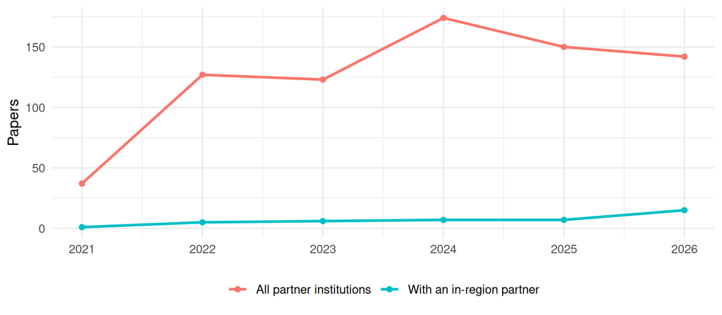

| Partner | Papers in topics |
| --- | --- |
| Colorado School of Mines | 296 |
| Los Alamos National Laboratory | 166 |
| Idaho National Laboratory | 127 |
| National Laboratory of the Rockies | 112 |
| Ames National Laboratory | 52 |
| University of Alaska Fairbanks | 29 |
| University of Alaska Anchorage | 17 |

## Technology base: patents

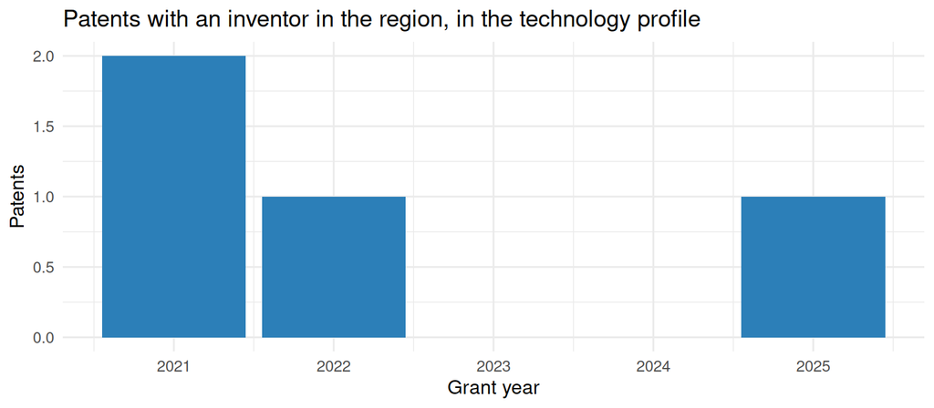

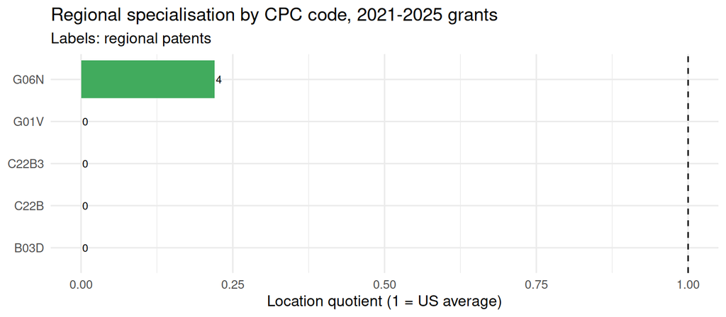

| Assignee | Regional patents in profile |
| --- | --- |
| AT&T Intellectual Property I, L.P. | 1 |
| AT&T Mobility II LLC | 1 |
| CISCO TECHNOLOGY, INC. | 1 |
| Verizon Patent and Licensing Inc. | 1 |

Partner-owned patents invented in the region: 10, of which 0 (0.0%) fall in the Engine’s technology profile.

## Competition

With 4 patents in the technology profile (2021-2025 grants), the Engine’s region would rank **53** among US states; its specialisation (LQ) is 0.2.

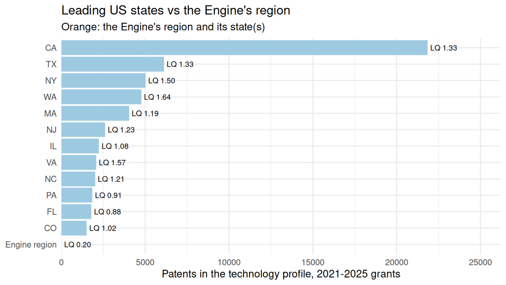

| Country | Share of US patents in profile | Share of world papers in topics |
| --- | --- | --- |
| US | 61.2% | 7.6% |
| CN | 7.9% | 29.2% |
| IN | 6.8% | 3.9% |
| JP | 5.5% | 1.9% |
| KR | 4.6% | 2.0% |
| CA | 3.9% | 2.7% |
| GB | 3.8% | 2.3% |
| DE | 3.3% | 3.2% |
| IL | 3.1% | NA |
| FR | 1.8% | 2.6% |

Patents: inventor countries on US grants in the profile (a patent counts for every country of its inventors). Papers: author countries of OpenAlex works in the Engine’s topics since the window start.

## Data and limitations

- People: PIs and Co-PIs from the NSF Award API; leadership listed on the Engine’s website. Roles come from titles and organisations, revised with OpenAlex evidence.
- Partners: as listed on the Engine’s website, plus organisations of team members. Some Engines publish partner logos without names.
- Region: the Engine’s counties where the list is known (NEO-SMART: 18 Northeast Ohio counties; STELLAR: 11 counties from the NSF abstract), otherwise its states (state-level proxy).
- Technology profile: v1 (switch versions in the header). Partner papers and regional patents depend on it: v1 uses mostly CPC subclasses, the v3.1 core uses CPC main groups, which are narrower, so it counts fewer patents and the LQ of a small region rests on few patents.
- Papers: OpenAlex; partner papers are restricted to the Engine’s OpenAlex topics.
- Patents: USPTO grants 2021-2025; inventor locations from PatentsView; pre-grant publications are not included.